# pH_sept_QC_exploration

```r
library(googledrive)
library(tidyverse)
name_of_transcription_file_on_drive = "pH_data_sept_claude_transcribed_AG_manually_verified_20261118" # copy the file's name exactly as it appears on google drive

dribble = drive_get(name_of_transcription_file_on_drive, shared_drive = 'Bogar Lab') # get necesary data for downloading
```

```
## ! Using an auto-discovered, cached token.
```

```
##   To suppress this message, modify your code or options to clearly consent to
##   the use of a cached token.
```

```
##   See gargle's "Non-interactive auth" vignette for more details:
```

```
## ℹ The googledrive package is using a cached token for 'agoodman@ucdavis.edu'.
```

```
## ✔ The input `path` resolved to exactly 1 file.
```

```r
local_path <- paste0("Inputs/",
                     name_of_transcription_file_on_drive,
                     "_downloaded-",
                     format(Sys.Date(), "%Y%m%d"),
                     ".csv") #define what this local file name will be, with today's date

drive_download(dribble, type = "csv", path = local_path, overwrite = TRUE)
```

```
## File downloaded:
```

```
## • 'pH_data_sept_claude_transcribed_AG_manually_verified_20261118'
##   <id: 1NOI-jiwxPDqZrH6IgpEg1hoctvKEy7TycAX64KNaFZU>
```

```
## Saved locally as:
```

```
## • 'Inputs/pH_data_sept_claude_transcribed_AG_manually_verified_20261118_downloaded-20261118.csv'
```

```r
transcribed_data = read.csv(local_path)
```

The following code was written by claude. Interjections in the markdown file between code chunks are me (AG).

To start, I uploaded a copy of this^ csv to claude directly and gave following prompt: “Ok! I went through your whole list and checked on everything. I also manually verified values in all but the notes-containing columns. Here’s the final version of the spreadsheet. I have this csv in my R environment as a dataframe called”transcribed_data”. Can you write commented tidyverse code for me that will pull select insights from these data? I want to know a) if there are any rows in which the first and second measurements differ by 0.15 or more, and b) how different the pH measurements were for different subsamples of the same sample.”

Iteratively, I gave smaller additional prompts asking to add or edit chunks of the code I recieved after the first prompt. The following code chunks are an amalgamation (pieced together by me) of the code claude gave me after the first prompt.

```r
# =============================================================================
# pH data insights
#   a) rows where the first and second pH measurements differ by >= 0.15
#   b) how much pH varied across subsamples of the same sample
#
# Assumes the verified CSV is already loaded as `transcribed_data`.
# (The CSV was saved in Windows-1252 because of the degree sign in the notes.
#  If you ever re-read it: read_csv(path, locale = locale(encoding = "latin1")))
# =============================================================================

# ---- 0. Shared prep ---------------------------------------------------------
pH_data <- transcribed_data |>
  mutate(
    # make sure the pH columns are numeric
    across(c(pH_first_measurement, pH_second_measurement), as.numeric),

    # second minus first: positive = pH drifted UP between the two readings
    pH_diff = pH_second_measurement - pH_first_measurement,

    # round before comparing to a threshold! Floating point means that e.g.
    # 4.85 - 4.70 is stored as 0.14999999..., which would fail `>= 0.15`
    abs_pH_diff = round(abs(pH_diff), 2),

    # the pH we use for each measurement set = mean of the two readings
    pH_mean = (pH_first_measurement + pH_second_measurement) / 2,

    # CaCl2 blanks are rows too; flag them so they are easy to separate
    is_blank = Sample_ID == "blank"
  )
```

```r
# ---- a) Rows where first and second measurements differ by >= 0.15 ----------
large_diffs <- pH_data |>
  filter(abs_pH_diff >= 0.15) |>
  arrange(desc(abs_pH_diff)) |>
  select(
    Sample_ID, date, subsample, is_blank, fraction,
    pH_first_measurement, pH_second_measurement, pH_diff, abs_pH_diff,
    time_first, time_second, notes_transcription_verified_AG
  )

large_diffs  # view the rows
```

```
##    Sample_ID     date subsample is_blank  fraction pH_first_measurement
## 1    DSC_318 20261028         1    FALSE  30-50 cm                 5.89
## 2      blank 20261117         3     TRUE      <NA>                 5.12
## 3      blank 20261105         2     TRUE      <NA>                 5.16
## 4    DSC_206 20261028         1    FALSE  15-30 cm                 4.93
## 5    DSC_224 20261028         1    FALSE  30-50 cm                 5.31
## 6    DSC_305 20261028         1    FALSE   0-15 cm                 5.40
## 7      blank 20261020         1     TRUE      <NA>                 5.19
## 8      blank 20261029         1     TRUE      <NA>                 5.35
## 9    DSC_252 20261020         1    FALSE      <NA>                 4.94
## 10   DSC_308 20261105         2    FALSE   0-15 cm                 6.87
## 11   DSC_329 20261015         1    FALSE      <NA>                 5.22
## 12   DSC_339 20261027         1    FALSE 50-100 cm                 4.70
##    pH_second_measurement pH_diff abs_pH_diff time_first time_second
## 1                   6.75    0.86        0.86      15:01       17:48
## 2                   5.44    0.32        0.32      15:53       16:35
## 3                   5.46    0.30        0.30      16:07       19:54
## 4                   4.66   -0.27        0.27      13:39       16:28
## 5                   5.07   -0.24        0.24      14:37       16:52
## 6                   5.63    0.23        0.23      15:36       18:02
## 7                   4.97   -0.22        0.22       <NA>       18:56
## 8                   5.14   -0.21        0.21      12:11       13:52
## 9                   5.12    0.18        0.18      18:38       20:08
## 10                  7.04    0.17        0.17      18:39       20:23
## 11                  5.38    0.16        0.16      16:19       16:55
## 12                  4.85    0.15        0.15      14:27       15:22
##    notes_transcription_verified_AG
## 1                                y
## 2
## 3
## 4
## 5
## 6                                y
## 7
## 8
## 9
## 10
## 11                               y
## 12
```

```r
# How common are they overall? (blanks included here)
pH_data |>
  summarise(
    n_rows          = n(),
    n_large_diff    = sum(abs_pH_diff >= 0.15, na.rm = TRUE),
    pct_large_diff  = 100 * n_large_diff / n_rows,
    median_abs_diff = median(abs_pH_diff, na.rm = TRUE)
  )
```

```
##   n_rows n_large_diff pct_large_diff median_abs_diff
## 1    118           12       10.16949            0.03
```

Some of these ^ were re-done successfully. Find just the samples (excluding blanks) where ALL subsamples measured had large diffs

```r
# Sample_IDs where EVERY measured row (subsample) has a first/second diff >= 0.15
all_large_ids <- pH_data |>
  filter(!is_blank) |>                         # drop CaCl2 blanks
  group_by(Sample_ID) |>
  filter(all(abs_pH_diff >= 0.15)) |>          # keep samples whose rows are all large
  # filter(n() > 1) |>                         # uncomment to require 2+ subsamples
  distinct(Sample_ID)

# Keep only those samples' rows from the large_diffs table
large_diffs_all_subsamples <- large_diffs |>
  filter(!is_blank) |>
  semi_join(all_large_ids, by = "Sample_ID")

large_diffs_all_subsamples
```

```
##   Sample_ID     date subsample is_blank  fraction pH_first_measurement
## 1   DSC_252 20261020         1    FALSE      <NA>                 4.94
## 2   DSC_339 20261027         1    FALSE 50-100 cm                 4.70
##   pH_second_measurement pH_diff abs_pH_diff time_first time_second
## 1                  5.12    0.18        0.18      18:38       20:08
## 2                  4.85    0.15        0.15      14:27       15:22
##   notes_transcription_verified_AG
## 1
## 2
```

Ok at least one of these (probably DSC_252) didn’t get re-subsampled because there was a transcription error in my first round of claude transcriptions that I didn’t catch, which I just fixed today. DSC_339 didn’t get done, maybe because I selected diffs >0.15 instead of >= ?

```r
large_diffs <- pH_data |>
  filter(abs_pH_diff >= 0.15) |>
  arrange(desc(abs_pH_diff)) |>
  select(
    Sample_ID, date, subsample, is_blank, fraction,
    pH_first_measurement, pH_second_measurement, pH_diff, abs_pH_diff,
    time_first, time_second, notes_transcription_verified_AG
  )

large_diffs  # view the rows
```

```
##    Sample_ID     date subsample is_blank  fraction pH_first_measurement
## 1    DSC_318 20261028         1    FALSE  30-50 cm                 5.89
## 2      blank 20261117         3     TRUE      <NA>                 5.12
## 3      blank 20261105         2     TRUE      <NA>                 5.16
## 4    DSC_206 20261028         1    FALSE  15-30 cm                 4.93
## 5    DSC_224 20261028         1    FALSE  30-50 cm                 5.31
## 6    DSC_305 20261028         1    FALSE   0-15 cm                 5.40
## 7      blank 20261020         1     TRUE      <NA>                 5.19
## 8      blank 20261029         1     TRUE      <NA>                 5.35
## 9    DSC_252 20261020         1    FALSE      <NA>                 4.94
## 10   DSC_308 20261105         2    FALSE   0-15 cm                 6.87
## 11   DSC_329 20261015         1    FALSE      <NA>                 5.22
## 12   DSC_339 20261027         1    FALSE 50-100 cm                 4.70
##    pH_second_measurement pH_diff abs_pH_diff time_first time_second
## 1                   6.75    0.86        0.86      15:01       17:48
## 2                   5.44    0.32        0.32      15:53       16:35
## 3                   5.46    0.30        0.30      16:07       19:54
## 4                   4.66   -0.27        0.27      13:39       16:28
## 5                   5.07   -0.24        0.24      14:37       16:52
## 6                   5.63    0.23        0.23      15:36       18:02
## 7                   4.97   -0.22        0.22       <NA>       18:56
## 8                   5.14   -0.21        0.21      12:11       13:52
## 9                   5.12    0.18        0.18      18:38       20:08
## 10                  7.04    0.17        0.17      18:39       20:23
## 11                  5.38    0.16        0.16      16:19       16:55
## 12                  4.85    0.15        0.15      14:27       15:22
##    notes_transcription_verified_AG
## 1                                y
## 2
## 3
## 4
## 5
## 6                                y
## 7
## 8
## 9
## 10
## 11                               y
## 12
```

```r
# How common are they overall? (blanks included here)
pH_data |>
  summarise(
    n_rows          = n(),
    n_large_diff    = sum(abs_pH_diff >= 0.15, na.rm = TRUE),
    pct_large_diff  = 100 * n_large_diff / n_rows,
    median_abs_diff = median(abs_pH_diff, na.rm = TRUE)
  )
```

```
##   n_rows n_large_diff pct_large_diff median_abs_diff
## 1    118           12       10.16949            0.03
```

```r
# ---- b) pH differences between subsamples of the same sample ----------------
subsamples <- pH_data |>
  filter(!is_blank) |>
  # Every Sample_ID is its own sample (260A/260B and 332A/332B are treated as
  # separate samples, NOT as subsamples of 260/332), so group by Sample_ID
  # chronological order within each sample
  arrange(Sample_ID, date) |>
  group_by(Sample_ID) |>
  # keep only samples measured more than once
  filter(n() > 1) |>
  mutate(
    set_order       = row_number(),                 # 1 = earliest measurement set
    diff_from_first = pH_mean - first(pH_mean)      # later set minus earliest set
  ) |>
  ungroup()

# One row per sample: all pH values (chronological) and how far apart they are
sample_summary <- subsamples |>
  group_by(Sample_ID) |>
  summarise(
    n_sets   = n(),
    dates    = str_c(date, collapse = " | "),
    pH_means = str_c(sprintf("%.2f", pH_mean), collapse = " | "),
    pH_range = max(pH_mean) - min(pH_mean),   # max - min across subsamples
    pH_sd    = sd(pH_mean),
    # verified notes from each measurement set, in the same chronological order
    # as dates/pH_means, each prefixed with its date; blank notes show "(none)"
    notes    = str_c(
      date, ": ",
      if_else(
        is.na(notes_claude_transcription_not_verified_unless_marked
) | notes_claude_transcription_not_verified_unless_marked
 == "",
        "(none)",
        notes_claude_transcription_not_verified_unless_marked
      ),
      collapse = " || "
    ),
    .groups  = "drop"
  ) |>
  arrange(desc(pH_range))

sample_summary  # view the per-sample table
```

```
## # A tibble: 13 × 7
##    Sample_ID n_sets dates               pH_means    pH_range   pH_sd notes
##    <chr>      <int> <chr>               <chr>          <dbl>   <dbl> <chr>
##  1 DSC_318        2 20261028 | 20261117 6.32 | 5.84  0.480   0.339   "20261028:…
##  2 DSC_210        2 20261028 | 20261105 4.90 | 5.26  0.360   0.255   "20261028:…
##  3 DSC_329        2 20261015 | 20261117 5.30 | 5.62  0.315   0.223   "20261015:…
##  4 DSC_259        2 20261015 | 20261105 5.14 | 5.41  0.265   0.187   "20261015:…
##  5 DSC_206        2 20261028 | 20261117 4.79 | 5.00  0.205   0.145   "20261028:…
##  6 DSC_224        2 20261028 | 20261117 5.19 | 5.00  0.190   0.134   "20261028:…
##  7 DSC_340        2 20261020 | 20261105 5.22 | 5.36  0.140   0.0990  "20261020:…
##  8 DSC_209        2 20261028 | 20261105 5.03 | 4.89  0.130   0.0919  "20261028:…
##  9 DSC_220        2 20261029 | 20261105 5.07 | 5.15  0.0800  0.0566  "20261029:…
## 10 DSC_239        2 20261027 | 20261105 5.02 | 5.07  0.0550  0.0389  "20261027:…
## 11 DSC_248        2 20261027 | 20261105 4.86 | 4.88  0.0150  0.0106  "20261027:…
## 12 DSC_308        2 20261028 | 20261105 6.94 | 6.96  0.0150  0.0106  "20261028:…
## 13 DSC_305        2 20261028 | 20261117 5.52 | 5.52  0.00500 0.00354 "20261028:…
```

```r
# Overall: typical disagreement between subsamples
sample_summary |>
  summarise(
    n_samples          = n(),
    median_range       = median(pH_range),
    mean_range         = mean(pH_range),
    max_range          = max(pH_range),
    n_range_ge_0.15    = sum(round(pH_range, 2) >= 0.15)
  )
```

```
## # A tibble: 1 × 5
##   n_samples median_range mean_range max_range n_range_ge_0.15
##       <int>        <dbl>      <dbl>     <dbl>           <int>
## 1        13        0.140      0.173     0.480               6
```

```r
# Is there a direction? Are later subsamples systematically higher or lower
# than the earliest one?
subsamples |>
  filter(set_order > 1) |>
  summarise(
    n_comparisons = n(),
    mean_diff     = mean(diff_from_first),
    n_higher      = sum(diff_from_first > 0),
    n_lower       = sum(diff_from_first < 0)
  )
```

```
## # A tibble: 1 × 4
##   n_comparisons mean_diff n_higher n_lower
##           <int>     <dbl>    <int>   <int>
## 1            13    0.0504       10       3
```

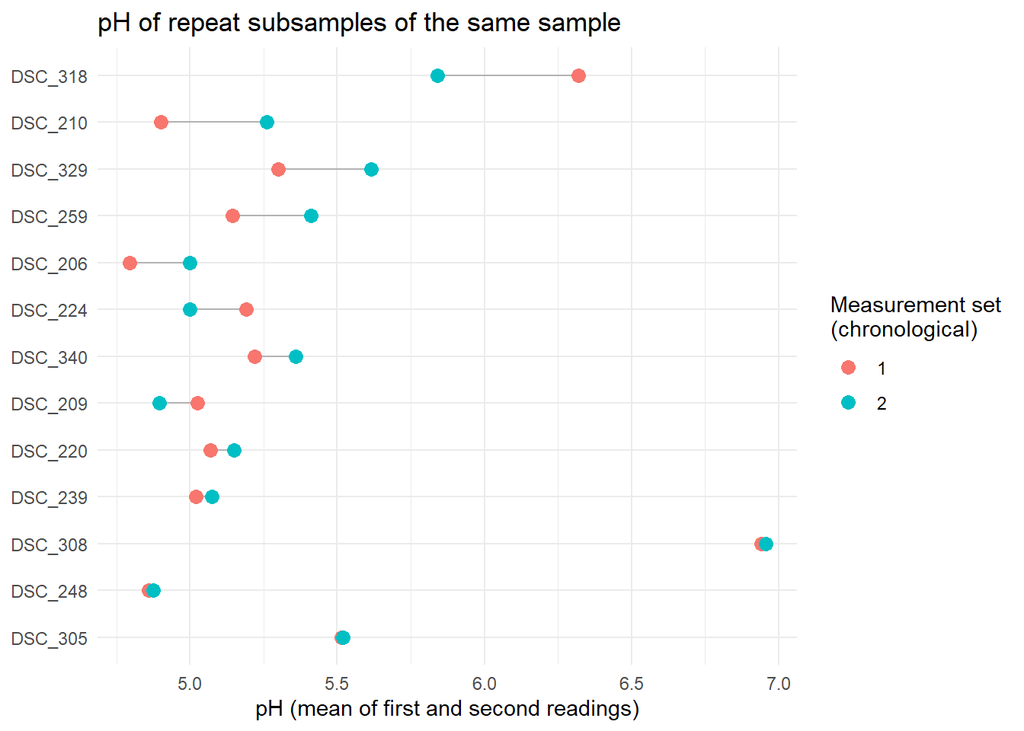

```r
# Quick visual: one row per sample, one dot per subsample, ordered by range
ggplot(
  subsamples,
  aes(
    x = pH_mean,
    y = fct_reorder(Sample_ID, pH_mean, .fun = \(x) max(x) - min(x))
  )
) +
  geom_line(aes(group = Sample_ID), colour = "grey70") +   # joins subsamples
  geom_point(aes(colour = factor(set_order)), size = 3) +
  labs(
    x = "pH (mean of first and second readings)",
    y = NULL,
    colour = "Measurement set\n(chronological)",
    title = "pH of repeat subsamples of the same sample"
  ) +
  theme_minimal()
```

Constrict this to the samples which I re-subsampled for quality control alone

```r
sample_summary <- sample_summary |>
  mutate(
    # Pull out "measuring 2nd pH subsample" plus everything after it, up to the
    # end of that measurement set's note. Sets in `notes` are joined with " || ",
    # so the lazy .*? stops at the next " || " (or at the end of the string),
    # which keeps text from other sets out of the result.
    # Samples where the phrase doesn't appear get NA.
    redo_reason = str_extract(
      notes,
      "measuring 2nd pH subsample.*?(?= \\|\\| |$)"
    )
  )

QC_results = sample_summary %>%
  filter(str_detect(redo_reason, "QC"))

QC_results
```

```
## # A tibble: 6 × 8
##   Sample_ID n_sets dates              pH_means pH_range  pH_sd notes redo_reason
##   <chr>      <int> <chr>              <chr>       <dbl>  <dbl> <chr> <chr>
## 1 DSC_210        2 20261028 | 202611… 4.90 | …   0.360  0.255  2026… measuring …
## 2 DSC_259        2 20261015 | 202611… 5.14 | …   0.265  0.187  2026… measuring …
## 3 DSC_340        2 20261020 | 202611… 5.22 | …   0.140  0.0990 2026… measuring …
## 4 DSC_220        2 20261029 | 202611… 5.07 | …   0.0800 0.0566 2026… measuring …
## 5 DSC_248        2 20261027 | 202611… 4.86 | …   0.0150 0.0106 2026… measuring …
## 6 DSC_308        2 20261028 | 202611… 6.94 | …   0.0150 0.0106 2026… measuring …
```

```r
# Overall: typical disagreement between subsamples
QC_results |>
  summarise(
    n_samples          = n(),
    median_range       = median(pH_range),
    mean_range         = mean(pH_range),
    max_range          = max(pH_range),
    n_range_ge_0.15    = sum(round(pH_range, 2) >= 0.15)
  )
```

```
## # A tibble: 1 × 5
##   n_samples median_range mean_range max_range n_range_ge_0.15
##       <int>        <dbl>      <dbl>     <dbl>           <int>
## 1         6        0.110      0.146     0.360               2
```

```r
# Is there a direction? Are later subsamples systematically higher or lower
# than the earliest one?
subsamples |>
  filter(set_order > 1) |>
  filter(str_detect(notes_claude_transcription_not_verified_unless_marked, "QC")) |>
  summarise(
    n_comparisons = n(),
    mean_diff     = mean(diff_from_first),
    n_higher      = sum(diff_from_first > 0),
    n_lower       = sum(diff_from_first < 0)
  )
```

```
## # A tibble: 1 × 4
##   n_comparisons mean_diff n_higher n_lower
##           <int>     <dbl>    <int>   <int>
## 1             6     0.146        6       0
```

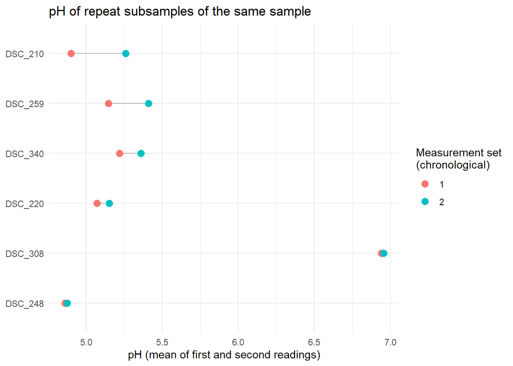

```r
# Quick visual: one row per sample, one dot per subsample, ordered by range
ggplot(
  subsamples %>% filter(Sample_ID %in% QC_results$Sample_ID),
  aes(
    x = pH_mean,
    y = fct_reorder(Sample_ID, pH_mean, .fun = \(x) max(x) - min(x))
  )
) +
  geom_line(aes(group = Sample_ID), colour = "grey70") +   # joins subsamples
  geom_point(aes(colour = factor(set_order)), size = 3) +
  labs(
    x = "pH (mean of first and second readings)",
    y = NULL,
    colour = "Measurement set\n(chronological)",
    title = "pH of repeat subsamples of the same sample"
  ) +
  theme_minimal()
```

asked claude to make me this visual ^ with the actual readings, not the means

What if I did that for all the samples

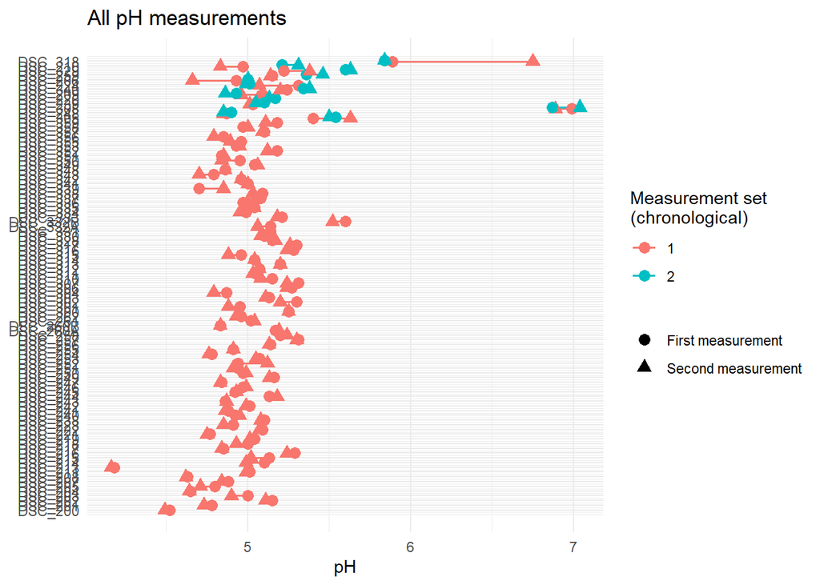

```r
all_measurements <- pH_data |>
  filter(!is_blank) |>
  # Every Sample_ID is its own sample (260A/260B and 332A/332B are treated as
  # separate samples, NOT as subsamples of 260/332), so group by Sample_ID
  # chronological order within each sample
  arrange(Sample_ID, date) |>
  group_by(Sample_ID) |>
  # keep only samples measured more than once
  mutate(
    set_order       = row_number(),                 # 1 = earliest measurement set
    diff_from_first = pH_mean - first(pH_mean)      # later set minus earliest set
  ) |>
  ungroup()

# ---- Reshape: one row per reading (first / second) per set -------------------
all_long <- all_measurements |>
  # two columns -> one `pH` column plus a `reading` label
  pivot_longer(
    cols      = c(pH_first_measurement, pH_second_measurement),
    names_to  = "reading",
    values_to = "pH"
  ) |>
  mutate(
    reading  = if_else(reading == "pH_first_measurement", "First measurement", "Second measurement"),
    # order samples by the range of their set means (same ordering as before;
    # pH_mean is the per-set mean, so its max - min is the sample's pH_range)
    sample_f = fct_reorder(Sample_ID, pH_mean, .fun = \(x) max(x) - min(x))
  ) |>
  # Numeric y position: one row per sample, with each measurement set nudged up
  # or down so overlapping sets stay visible
  group_by(Sample_ID) |>
  mutate(
    y_pos = as.numeric(sample_f) +
      0.3 * (set_order - (min(set_order) + max(set_order)) / 2)
  ) |>
  ungroup()

# ---- Plot ---------------------------------------------------------------------
ggplot(all_long, aes(x = pH, y = y_pos, colour = factor(set_order))) +
  # short line joining the first and second reading within the same set
  geom_path(aes(group = interaction(Sample_ID, set_order)), linewidth = 0.7) +
  # one point per reading; shape shows which reading it was
  geom_point(aes(shape = reading), size = 3) +
  # put sample names back on the y axis (it is numeric because of the nudging)
  scale_y_continuous(
    breaks = seq_along(levels(all_long$sample_f)),
    labels = levels(all_long$sample_f)
  ) +
  scale_shape_manual(values = c("First measurement" = 16, "Second measurement" = 17)) +
  labs(
    x      = "pH",
    y      = NULL,
    colour = "Measurement set\n(chronological)",
    shape  = NULL,
    title  = "All pH measurements"
  ) +
  theme_minimal()
```

Asked claude to improve this ^

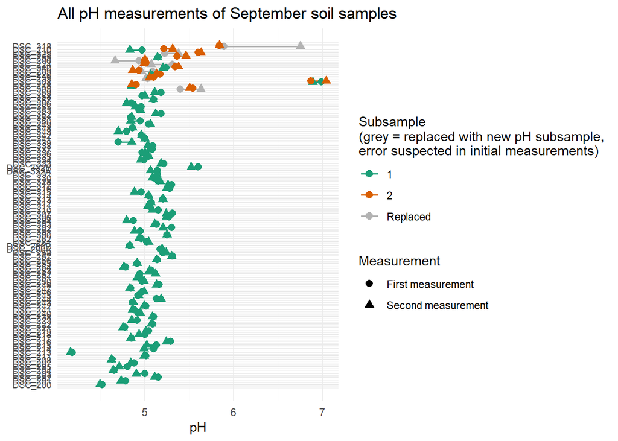

```r
# All samples: every measurement (first/second) in every measurement set,
# with sets greyed out when a later set was done to replace them.
# Needs `pH_data` from pH_insights.R.
# Terminology: a "measurement" is one pH value (first or second reading);
# a "measurement set" is one subsample's pair of measurements.

library(tidyverse)

# ---- 1. One row per measurement set -------------------------------------------
all_measurements <- pH_data |>
  filter(!is_blank) |>
  # each Sample_ID is its own sample; sets in chronological order
  arrange(Sample_ID, date) |>
  group_by(Sample_ID) |>
  mutate(
    set_order       = row_number(),                    # 1 = earliest set
    n_sets          = n(),
    pH_range        = max(pH_mean) - min(pH_mean),     # spread of set means
    diff_from_first = pH_mean - first(pH_mean),        # later set minus earliest set

    # TRUE if this set was done to replace an earlier one: either every set from
    # 11/17, or a set whose note says it replaces the first subsample data
    # (str_detect() gives NA for missing notes, so coalesce() turns that to FALSE)
    is_replacement  = date == 20261117 |
      coalesce(
        str_detect(
          notes_claude_transcription_not_verified_unless_marked,
          "to replace first subsample"
        ),
        FALSE
      ),

    # a set is "replaced" when the NEXT set of the same sample is a replacement
    replaced        = lead(is_replacement, default = FALSE)
  ) |>
  ungroup() |>
  mutate(
    # samples ordered by pH_range (same value on every row of a sample)
    sample_f   = fct_reorder(Sample_ID, pH_range),
    # colour key: grey for replaced sets, otherwise the set number
    set_status = if_else(replaced, "Replaced", as.character(set_order)),
    # numeric y position: one row per sample, sets nudged up/down so overlapping
    # sets stay visible
    y_pos      = as.numeric(sample_f) + 0.3 * (set_order - (n_sets + 1) / 2)
  )

# ---- 2. One row per measurement ------------------------------------------------
all_long <- all_measurements |>
  pivot_longer(
    cols         = c(pH_first_measurement, pH_second_measurement),
    names_to     = "measurement",
    names_pattern = "pH_(.*)_measurement",       # keeps "first" / "second"
    values_to    = "pH"
  ) |>
  mutate(measurement = str_c(str_to_sentence(measurement), " measurement")) |>
  # draw replaced (grey) sets first so they sit underneath the others
  arrange(desc(replaced))

# ---- 3. Plot ---------------------------------------------------------------------
all_sept_pH_plot = ggplot(all_long, aes(x = pH, y = y_pos, colour = set_status)) +
  # short line joining the two measurements within a measurement set
  geom_path(aes(group = interaction(Sample_ID, set_order)), linewidth = 0.7) +
  # one point per measurement; shape shows first vs second
  geom_point(aes(shape = measurement), size = 2.5) +
  # sample names back on the y axis (numeric because of the nudging)
  scale_y_continuous(
    breaks = seq_along(levels(all_long$sample_f)),
    labels = levels(all_long$sample_f)
  ) +
  scale_colour_manual(
    values = c("1" = "#1b9e77", "2" = "#d95f02", "3" = "#7570b3", "Replaced" = "grey70")
  ) +
  scale_shape_manual(
    values = c("First measurement" = 16, "Second measurement" = 17)
  ) +
  labs(
    x      = "pH",
    y      = NULL,
    colour = "Subsample\n(grey = replaced with new pH subsample,\nerror suspected in initial measurements)",
    shape  = "Measurement",
    title  = "All pH measurements of September soil samples"
  ) +
  theme_minimal() +
  theme(axis.text.y = element_text(size = 7))

all_sept_pH_plot
```

```r
# With ~100 samples the plot needs to be tall, e.g.:
ggsave("Results/all_sept_pH_measurements.png", plot = all_sept_pH_plot, height = 0.17 * nlevels(all_long$sample_f) + 2, width = 8)
```

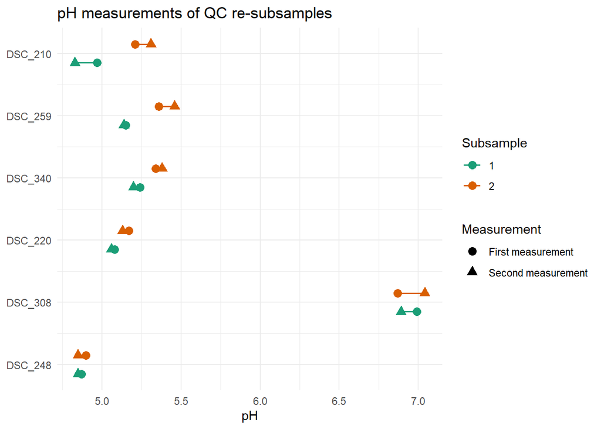

```r
# QC re-subsamples only, reusing `all_long` from the all-samples chunk
# (all_measurements_plot.R) instead of rebuilding the same data a second time.
# Needs `all_long` (from that chunk) and `QC_results` (from your QC chunk).
# Terminology: a "measurement" is one pH value (first or second); a
# "measurement set" is one subsample's pair of measurements.

# ---- 1. Shared plotting function (replaces the ggplot() call in BOTH chunks) --
plot_measurements <- function(data, title) {
  ggplot(data, aes(x = pH, y = y_pos, colour = set_status)) +
    # short line joining the two measurements within a measurement set
    geom_path(aes(group = interaction(Sample_ID, set_order)), linewidth = 0.7) +
    # one point per measurement; shape shows first vs second
    geom_point(aes(shape = measurement), size = 3) +
    # sample names back on the y axis (numeric because of the nudging)
    scale_y_continuous(
      breaks = seq_along(levels(data$sample_f)),
      labels = levels(data$sample_f)
    ) +
    scale_colour_manual(
      values = c("1" = "#1b9e77", "2" = "#d95f02", "3" = "#7570b3", "Replaced" = "grey70")
    ) +
    scale_shape_manual(
      values = c("First measurement" = 16, "Second measurement" = 17)
    ) +
    labs(
      x      = "pH",
      y      = NULL,
      colour = "Subsample",
      shape  = "Measurement",
      title  = title
    ) +
    theme_minimal()
}

# ---- 2. QC samples only ----------------------------------------------------------
QC_long <- all_long |>
  filter(Sample_ID %in% QC_results$Sample_ID) |>
  mutate(
    # drop levels of samples that were filtered out; as.numeric() then
    # renumbers the remaining samples 1..k, so there are no gaps on the y axis
    # (the relative order by pH_range is unchanged)
    sample_f = fct_drop(sample_f),
    y_pos    = as.numeric(sample_f) + 0.3 * (set_order - (n_sets + 1) / 2)
  )

plot_measurements(QC_long, "pH measurements of QC re-subsamples")
```

```r
# In the all-samples chunk, the ggplot() call becomes:
# plot_measurements(all_long, "All pH measurements")
```

asked claude to reflect the distance between dates somehow

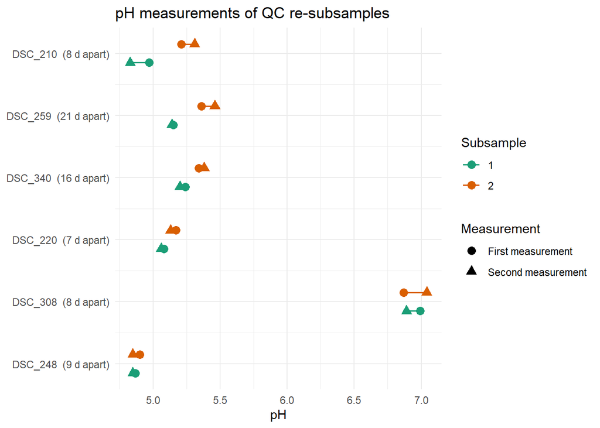

```r
# QC re-subsamples only, reusing `all_long` from the all-samples chunk.
# New: each sample's y-axis label also shows how many days apart its subsamples
# were measured. Needs `all_long` and `QC_results`.
# Terminology: a "measurement" is one pH value (first or second); a
# "subsample" is one subsample's pair of measurements.

# ---- 1. Shared plotting function ----------------------------------------------
# show_days = TRUE adds "(N d apart)" to the y-axis labels; it needs a
# `days_between` column in `data` (created in section 2 below).
plot_measurements <- function(data, title, show_days = FALSE) {

  # y-axis labels: sample names, optionally with the gap between subsamples
  y_labels <- levels(data$sample_f)
  if (show_days) {
    days <- data |>
      distinct(sample_f, days_between) |>
      arrange(sample_f)                      # same order as the factor levels
    y_labels <- str_c(days$sample_f, "  (", days$days_between, " d apart)")
  }

  ggplot(data, aes(x = pH, y = y_pos, colour = set_status)) +
    # short line joining the two measurements within a subsample
    geom_path(aes(group = interaction(Sample_ID, set_order)), linewidth = 0.7) +
    # one point per measurement; shape shows first vs second
    geom_point(aes(shape = measurement), size = 3) +
    # sample names (and days apart) on the y axis; numeric because of the nudging
    scale_y_continuous(
      breaks = seq_along(levels(data$sample_f)),
      labels = y_labels
    ) +
    scale_colour_manual(
      values = c("1" = "#1b9e77", "2" = "#d95f02", "3" = "#7570b3", "Replaced" = "grey70")
    ) +
    scale_shape_manual(
      values = c("First measurement" = 16, "Second measurement" = 17)
    ) +
    labs(
      x      = "pH",
      y      = NULL,
      colour = "Subsample",
      shape  = "Measurement",
      title  = title
    ) +
    theme_minimal()
}

# ---- 2. QC samples only ----------------------------------------------------------
QC_long <- all_long |>
  filter(Sample_ID %in% QC_results$Sample_ID) |>
  mutate(
    # drop levels of filtered-out samples so the y axis has no gaps
    sample_f = fct_drop(sample_f),
    y_pos    = as.numeric(sample_f) + 0.3 * (set_order - (n_sets + 1) / 2),
    # `date` looks like 20261105; ymd() turns it into a real date
    date_parsed = lubridate::ymd(date)
  ) |>
  # days between a sample's first and last subsample
  group_by(Sample_ID) |>
  mutate(days_between = as.numeric(max(date_parsed) - min(date_parsed))) |>
  ungroup()

plot_measurements(QC_long, "pH measurements of QC re-subsamples", show_days = TRUE)
```